# 4. El concepto de ‘Salud’

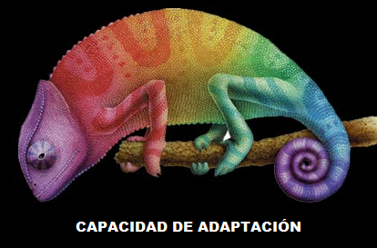

Fuente: Web ademto.org

## Actividad 1: El concepto de salud según la OMS

La OMS (Organización Mundial de la Salud), creada para promover niveles óptimos de salud para los humanos, propone una definición de salud que tiene que ver con estar “completamente” bien en varios aspectos.

Busca esta definición y escríbela en la carpeta. Luego subraya los 3 aspectos en los que se busca el bienestar.

## Actividad 2: Una opinión diferente

Alejandro Jadad, un médico y científico colombiano, nos comparte en este [video](https://www.youtube.com/watch?v=vce9cH-LnZo) un nuevo concepto de salud basado en investigaciones, experiencias y diálogo entre un grupo de especialistas. Esta idea contrasta con la definición de la OMS.

Mira el video y responde brevemente las siguientes preguntas:

1. ¿De dónde viene la palabra salud?
2. ¿Qué le hizo replantearse al autor la definición de salud?
3. ¿Cuántas personas se reunieron (encerraron) a debatir hasta lograr una nueva definición que resulte útil?
4. Escriba la nueva definición de salud que salió de esta reunión
5. ¿Por qué bajo esta definición uno puede considerarse saludable hasta el último suspiro?

## Actividad 3: Conclusiones

Como se ve no hay un concenso total sobre la definción de “salud”. La definición promovida por el Dr. Jadad parece ser también buena y razonable. Tampoco hay que olvidar que a todo esto hay que sumarle lo que aprendimos en la guía anterior sobre la felicidad, la cual está relacionada con la buena calidad de las relaciones y que eso además influye positivamante en la salud.

Copia este texto que es una especie de conclusión de lo que vimos hasta ahora y completa cada “____” con una sola palabra que sea adecuada.

“La definición de salud de la ____ pone el acento en el bienestar completo en distintos aspectos. La definición promovida por el Dr. Alejando Jadad se focaliza en que uno es saludable cuando es ____ de adaptarse y manejar los desafíos de la vida aunque no siempre uno esté perfectamente bien. Independientemente de la definición de salud que se prefiera también aprendimos que la”Felicidad profunda” está en cultivar buenas y profundas ____ con todas las personas.”